# Zi Grafiken und Plots im Corporate Design

Dr. Lars E. Kroll

2019-07-04

[figure not shown]

# Hintergrund

Das Paket `zicolors` ermöglicht es Grafiken im Stil des Zi Corporate Designs mit dem Paket ggplot2 in R zu erstellen. Es ermöglicht einfache Anpassungen der Syntax und gibt allgemeine Stilvorgaben, die sich am Stil von Infografiken in Zeitungen orientieren. Bei Bedarf steht zudem ein klassischerer Stil zur Verfügung, der eine modernisierte Form von Charts in Excel ist. In dieser Übersicht werden die verschiedenen Anwendungsmöglichkeiten für den Stil dargestellt.

Der Stil orientiert sich an einem vergleichbaren Stil der [BBC](https://bbc.github.io/rcookbook/).

# Installation

Die Installation des Stiles erfolgt anhand eines im Netzwerk bereitgestellten Paketes mit dem Paket `devtools’ von R.

```r
library("devtools")
library("ggplot2")
library("dplyr")
library("tidyr")
library("readxl")
library("knitr")
library("kableExtra")
library("ggrepel")
library("stringr")
devtools::install_local(path="G:/Austausch/FB3/13 Software/zicolors")
```

# Einbindung des Stiles

Zur Anwendung und Installation müssen die R Pakete tidyverse, devtools und extrafonts verfügbar sein. Die weiteren Libraries sind optional.

## Libraries

Hinweis: Damit die Windows-Schriftarten erkannt werden, muss extrafont einmal die lokal installierten Schriftarten importieren. Das geht mit `extrafont::font_import()` und dauert ein paar Minuten.

```r
library("zicolors")
library("extrafont")
loadfonts(device="win", quiet=T)
```

# Tabellen

Als Beispieldaten für die vorliegenden Analysen wird ein aggregierter Auszug aus der ARGO-Datenstelle zum Theme Krebsfrüherkennung verwendet, der für die Grafik des Monats März 2019 verwendet wird. Linda Zhu hat dazu die Daten aus der ARGO-Datenstelle exportiert.

Es werden zwei Tabellen importiert, die in der mit dem Paket mitgelieferten MS Excel Datei als Reiter implementiert wurden.

```r
Darmkrebsvorsorge_gesamt <-
  readxl::read_excel("G:/Austausch/FB3/13 Software/zicolors/data/Darmkrebsvorsorge Anzahl Patienten.xlsx",
                     sheet = "GOP 01730-01748") %>% gather(Jahr,Patienten,3:dim(.)[2])
Darmkrebsvorsorge_gesamt %>% head() %>%
   kable() %>%   kable_styling() %>% row_spec(0, bold = T, color = "white", background = zi_cols("ziblue"))
```

| GOP | Beschreibung | Jahr | Patienten |
| --- | --- | --- | --- |
| 01730 | Krebsfrüherkennungs- Untersuchung bei der Frau | 2009 | 14731329 |
| 01731 | Krebsfrüherkennungs- Untersuchung beim Mann | 2009 | 3474866 |
| 01732 | Gesundheitsuntersuchung | 2009 | 9917176 |
| 01733 | Zytologische Untersuchung (Krebsvorsorge) | 2009 | 14537094 |
| 01734 | Untersuchung auf Blut im Stuhl | 2009 | 4304794 |
| 01735 | Beratung gemäß § 4 der Chroniker-Richtlinie zu Früherkennungsuntersuchungen für nach dem 1. April 1987 geborene Frauen | 2009 | 86611 |

```r
Darmkrebsvorsorge_Patienten <- readxl::read_excel("G:/Austausch/FB3/13 Software/zicolors/data/Darmkrebsvorsorge Anzahl Patienten.xlsx",
                                                  sheet = "GOP 01741") %>%
  gather(Jahr,Patienten,3:dim(.)[2])  %>% mutate(Patienten=ifelse(Patienten=="<30",NA,as.numeric(Patienten)))
Darmkrebsvorsorge_Patienten %>% head() %>%   kable() %>%
  kable_styling() %>% row_spec(0, bold = T, color = "white", background = zi_cols("ziblue"))
```

| Geschlecht | Alter | Jahr | Patienten |
| --- | --- | --- | --- |
| unbekannt | 40 bis 59 Jahre | 2009 | 643 |
| unbekannt | 60 bis 79 Jahre | 2009 | 1259 |
| unbekannt | 80 und mehr Jahre | 2009 | 75 |
| männlich | 40 bis 59 Jahre | 2009 | 64699 |
| männlich | 60 bis 79 Jahre | 2009 | 145179 |
| männlich | 80 und mehr Jahre | 2009 | 7100 |

# Grafiken

## Grafikstile

Es gibt aktuell drei verschiedene Stile:

- `theme_zi()` (Standard für Infografiken und Präsentationen)
- `theme_zi_titels()` (Standard für klassische Grafiken mit Achsenbeschriftung)
- `theme_zi_void()` (Grafiken ohne Achsen und Hilfslinien)

## Farboptionen für Skalen in Grafiken

Anhand der ggplot2-Skalen `scale_fill_zi(FARB_NAME)` und `scale_color_zi(FARB_NAME)` können Plots mit Standard-Farbskalen, die sich an den Vorgaben des Zi Corporate Designs orientieren erzeugt werden. Die Skalen gehen von diskreten Variablen als Basis für die Farbkodierung aus. Sofern Plots auf Basis kontinuierlicher Variablen erzeugt werden sollen, muss die Option `discrete=FALSE` verwendet werden (bspw. also `scale_fill_zi(COLOR_SCHEME_NAME, discrete=FALSE)`).

### Übersicht

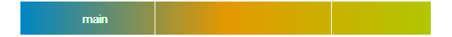

[figure not shown]

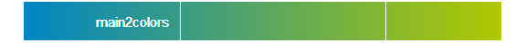

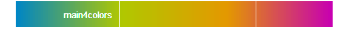

[figure not shown]

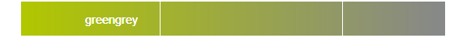

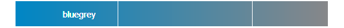

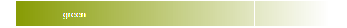

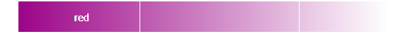

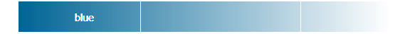

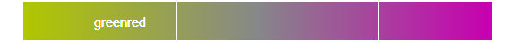

### Gezieltes Anwählen einzelner Farben

Einzelne Farben können mit dem Befehl `zi_cols()` beliebig verwendet werden. Bswp. `zi_cols("zidarkblue")`.

# Beispiele für Grafiken

## Balkendiagramme

### einfach

Ein simples Balkendiagramm. Wichtig ist, dass beim Diagramm im Standard keine Achensbeschriftungen verwendet werden. Dies setzt voraus, dass der Titel und Untertitel der Abbildung **selbsterklärend** ist.

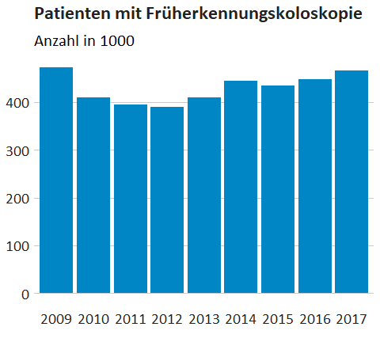

```r
Darmkrebsvorsorge_gesamt %>% filter(GOP=="01741") %>% group_by(Jahr) %>%
  summarise(Patienten=sum(Patienten, na.rm=T)/1000) %>%
  ggplot(., aes(x=Jahr,y=Patienten)) +
  geom_bar(stat="identity", fill=zi_cols("ziblue")) +
  theme_zi() +
  labs(title="Patienten mit Früherkennungskoloskopie", subtitle="Anzahl in 1000")
```

### mit Achsenbeschriftungen

Falls das nicht möglich ist, sollte das alternative Thema `theme_zi_titels()` verwendet werden, dass Achsenbeschriftungen enthält.

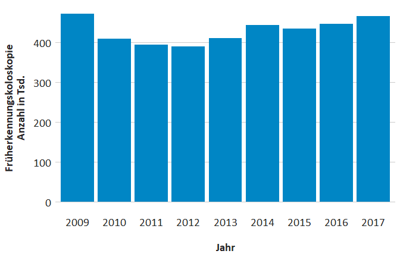

```r
Darmkrebsvorsorge_gesamt %>% filter(GOP=="01741") %>% group_by(Jahr) %>%
  summarise(Patienten=sum(Patienten, na.rm=T)/1000) %>%
  ggplot(., aes(x=Jahr,y=Patienten)) +
  geom_bar(stat="identity", fill=zi_cols("ziblue")) +
  theme_zi_titels() +
  labs(y="Früherkennungskoloskopie\nAnzahl in Tsd.", x="Jahr")
```

### Achsenlinien

Sollten **horizontale Achsenlinien** gewünscht sein, können diese mit den Funktion `geom_hline()` erhalten werden. Vertikale Achenlinen können bei Bedarf analog mit `geom_vline()` erzeugt werden.

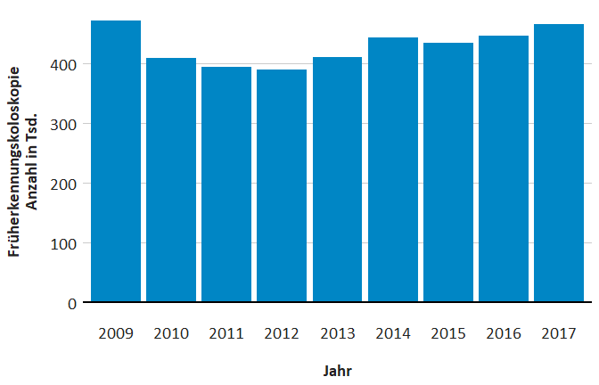

```r
Darmkrebsvorsorge_gesamt %>% filter(GOP=="01741") %>% group_by(Jahr) %>%
  summarise(Patienten=sum(Patienten, na.rm=T)/1000) %>%
  ggplot(., aes(x=Jahr,y=Patienten)) +
  geom_bar(stat="identity", fill=zi_cols("ziblue")) +
  theme_zi_titels() +
  labs(y="Früherkennungskoloskopie\nAnzahl in Tsd.", x="Jahr") +
  geom_hline(yintercept = 0, size=0.75)
```

### Hervorhebungen

Ein einzelner Balken lässt sich durch einfügen einer `ifelse()` Bedingung hervorheben. Für komplexere Bedingungen kann ggf. das Paket `gghighlights()` genutzt werden ((Link)[https://yutannihilation.github.io/gghighlight/articles/gghighlight.html]).

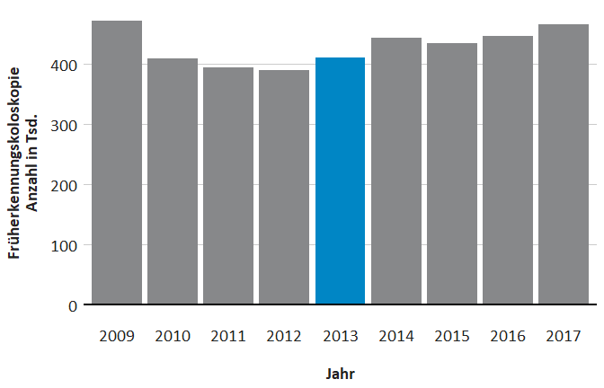

```r
Darmkrebsvorsorge_gesamt %>% filter(GOP=="01741") %>% group_by(Jahr) %>%
  summarise(Patienten=sum(Patienten, na.rm=T)/1000) %>%
  ggplot(., aes(x=Jahr,y=Patienten, fill=ifelse(.$Jahr==2013,"blau","grau"))) +
  geom_bar(stat="identity") + guides(fill=F) +
  theme_zi_titels() + scale_fill_zi("bluegrey") +
  labs(y="Früherkennungskoloskopie\nAnzahl in Tsd.", x="Jahr") +
  geom_hline(yintercept = 0, size=0.75)
```

## Liniendiagramme

Für die Darstellung von Zeitreihen bietet sich generell eher ein Liniendiagramm an. Generell ist auch hier zu beachten, dass die Eingängigkeit der Darstellung profitiert, wenn die Legende in den Plot integriert wird.

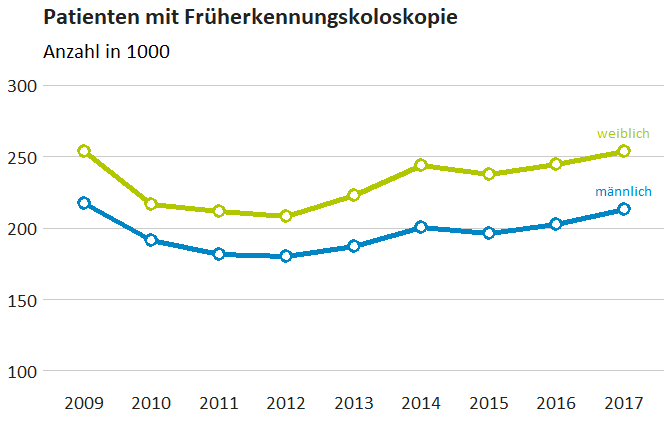

```r
Darmkrebsvorsorge_Patienten %>%
  mutate(Geschlecht=as.character(Geschlecht)) %>%
  filter(Geschlecht %in% c("männlich","weiblich")) %>%
  group_by(Geschlecht,Jahr) %>% summarise(Patienten=sum(Patienten, na.rm=T)/1000) %>%
  ggplot(., aes(x=Jahr,y=Patienten, color=Geschlecht, group=Geschlecht)) +
  geom_line(size=2) +
  geom_point(shape = 21,size=3,fill="White",stroke=2) +
  theme_zi() +
  labs(title="Patienten mit Früherkennungskoloskopie", subtitle="Anzahl in 1000") +
  scale_color_zi("main2colors", guide=F) + scale_y_continuous(breaks=seq(100,300,50),
                                                              limits=c(100,300)) +
  geom_label(data=. %>% filter(Jahr==max(Jahr)) , aes(label = Geschlecht),
             label.size = NA, vjust=-.5,
             family="Calibri",
             size = 4)
```

Um Teilgruppen zu vergleichen, sollte generell die Funktion facets genutzt werden. Die Textgröße wurde zudem mit der Option `fontsize=11` verkleinert. Die Labels wurden im Plot mit dem Paket `ggrepel` gesetzt, um eine Überschneidung mit den Daten zu verhindern.

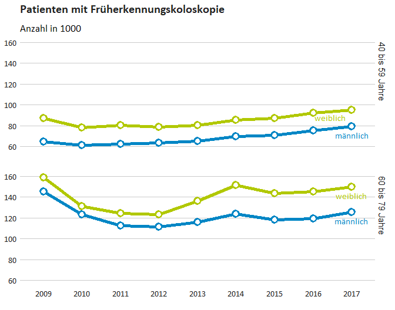

```r
Darmkrebsvorsorge_Patienten %>%
  mutate(Geschlecht=as.character(Geschlecht),
         Alter = as.character(Alter)) %>%
  filter(Geschlecht %in% c("männlich","weiblich")) %>%
  filter(Alter %in% c("40 bis 59 Jahre","60 bis 79 Jahre")) %>%
  group_by(Geschlecht,Alter,Jahr) %>% summarise(Patienten=sum(Patienten, na.rm=T)/1000) %>%
  ggplot(., aes(x=Jahr,y=Patienten, color=Geschlecht, group=Geschlecht)) +
  geom_line(size=2) +
  facet_grid(Alter~. ) + # , scales = "free_y"
  geom_point(shape = 21,size=3,fill="White",stroke=2) +
  theme_zi(fontsize = 11) +
  labs(title="Patienten mit Früherkennungskoloskopie", subtitle="Anzahl in 1000") +
  scale_color_zi("main2colors", guide=F) +
  geom_label_repel(data=. %>% filter(Jahr==max(Jahr)) , aes(label = Geschlecht),
             label.size = NA, vjust=0.4, fill=NA,
             family="Calibri",
             size = 4) +
  theme(panel.spacing = unit(2, "lines"))
```

### Kaplan-Meier-Plots (Survivalanalyse)

Etwas komplexer ist die Darstellung der Kaplan-Meier-Kurven bei einer Survivalanalyse. Folgender Code gibt ein Beispiel für die Adaption eines solchen Plots mit dem Paket `survminer` und dem Beispieldatensatz `ovarian`:

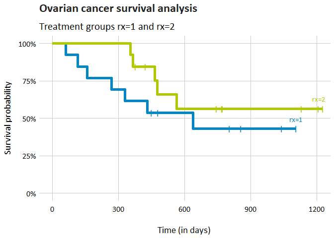

```r
library(survival)
data(ovarian)
library(survminer)

my_surv <- Surv(ovarian$futime, ovarian$fustat) # make a survival-object
my_cox <- coxph(my_surv ~ rx, data=ovarian) # fit a Cox-prop.-hazard-model
my_fit <- survfit(my_surv ~ rx, conf.type="log-log", data=ovarian) # create a survfit-object for plotting

ggsp <- ggsurvplot(my_fit, censor.shape="I")
ggsp_data <- ggsp$plot$data # we need to extract the data from the ggsurvplot-object
ggsp_zi <- ggsurvplot(my_fit, censor.shape="I", size=2)$plot + theme_zi_titels() +
  theme(panel.grid.major.x = element_line(size=0.1, color="#cbcbcb"),
        panel.grid.major.y = element_line(size=0.1, color="#cbcbcb")) + # display vertical lines since time points between curves are not aligned
  scale_color_zi(guide=FALSE) + # use zi color scheme
  scale_y_continuous(labels = scales::percent) + # display percent instead of 0-1-probability
  labs(title="Ovarian cancer survival analysis", subtitle="Treatment groups rx=1 and rx=2", x="Time (in days)") +
  geom_label_repel(data = . %>% filter(time %in% aggregate(time~strata, data=ggsp_data, max)$time),
             aes(label = strata, color=strata),
             label.size = NA, vjust=-0.5, fill=NA,
             family="Calibri", segment.color = NA,
             size = 4) # this adds the grouping at the endpoints of lines
ggsp_zi
```

## Visualisierung von Veränderungen

Um Veränderungen zu visualisieren bieten sich sog. dumbbell charts an. Sie zeigen für heterogene Outcomes Veränderungen zwischen zwei Zeitpunkten an. Wichtig ist bei der Konstruktion darauf zu achten, zuerst die Verbindungliene und anschließend die Punkte zu definieren. Um Labels besser lesbar zu machen, wurde der Plot mit `coord_flip()` gekippt und die Labels mit `stringr::str_trunc()` gekürzt.

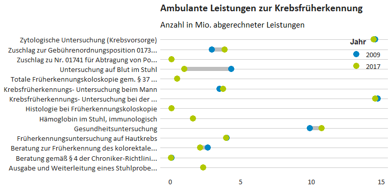

```r
dumbbell_plot <- Darmkrebsvorsorge_gesamt %>% filter(Jahr %in% c(min(Jahr),max(Jahr)))  %>% filter(!is.na(Patienten)) %>%
    ggplot(aes(x=paste(str_trunc(Beschreibung,45, "right")),
               y=Patienten/1000000,
               color=Jahr,
               group=GOP)) +
  geom_line(color="grey", size=3) +
  geom_point(size=4) +
  theme_zi(fontsize = 11) + scale_color_zi("main2colors") + coord_flip() +
  labs(title="Ambulante Leistungen zur Krebsfrüherkennung",
       subtitle="Anzahl in Mio. abgerechneter Leistungen")     +
  theme(legend.position =c(.9,.85) ,
        )

dumbbell_plot
```

## Boxplots

Boxplots sind besonders geeignet für den Vergleich von Gruppen, wenn nominalskalierte Variablen verglichen werden sollen (und sind oft gegenüber Balkendiagrammen oder Dynamiteplots vorzuziehen).

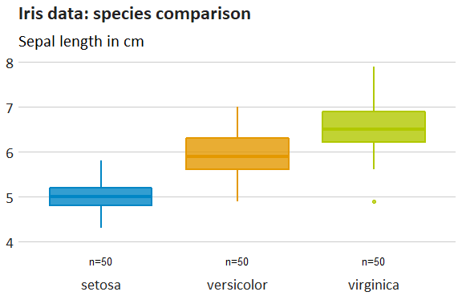

```r
data(iris)
library(EnvStats) # to display sample sizes
ggplot(data=iris, aes(x=Species, y=Sepal.Length, fill=Species,color=Species)) + geom_boxplot(lwd=1, fatten=1.5, alpha=.8) + theme_zi() +
  scale_fill_zi(guide=FALSE) +scale_color_zi(guide=FALSE) +
  labs(title="Iris data: species comparison", subtitle="Sepal length in cm") +
  stat_n_text(y.expand.factor=0.2, size=3.5)
```

## Infografiken

Mit den Daten der KM-6 Statistik und dem Paket `ggwaffle` lassen sich die Möglichkeiten von R für die Erstellung von Infografiken verdeutlichen.

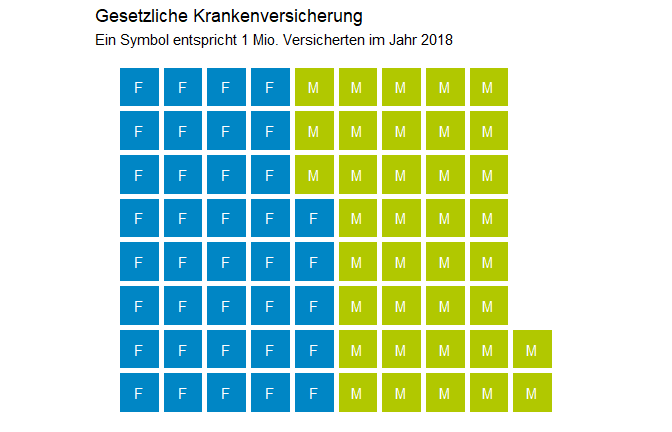

```r
library("ggwaffle")
KM6_2018 <- readr::read_csv2("G:/Austausch/FB3/14 Daten/KM6_Statistik/KM6_aufbereitet.csv") %>%
  filter(Jahr==2018) %>% group_by(Versichertengruppe,Geschlecht) %>% summarise(Anzahl=sum(Anzahl))
KM6_2018.waffle <- KM6_2018 %>% mutate(Anzahl=floor(Anzahl/1000000)) %>%
  slice(rep(1:n(), each = Anzahl)) %>% arrange(Geschlecht,Versichertengruppe) %>%   bind_cols(.,waffle_iron(.,aes_d(group = Geschlecht)) %>% arrange(group) )

ggplot(KM6_2018.waffle %>% arrange(x,y), aes(x, y, fill = Geschlecht)) +
  geom_waffle(show.legend = F)  + coord_fixed() + theme_void() +  geom_text(aes(label=ifelse(Geschlecht=="Männer","M","F")),color="White") + scale_fill_zi() +
  labs(title="Gesetzliche Krankenversicherung",
       subtitle="Ein Symbol entspricht 1 Mio. Versicherten im Jahr 2018")
```

Mit dem Waffle Plot können auch Symbole zur Veranschaulichung des Inhalts genutzt werden. Hierfür steht das Paket `emojifont` zur Verfügung, dessen Output allerdings nicht von RStudio angezeigt wird.

## Thematische Karten

Thematische Karten visualisieren die räumliche Verteilung von Indikatoren. Sie können in R mit öffentlich verfügbaren Shape Files (http://www.geodatenzentrum.de/) erstellt einfach mit dem Paket `sf` erstellt werden. Intro zum sf Paket (hier)[https://r-spatial.github.io].

### Einbindung von Shapefiles in R

Es gibt verschiedene Ansätze, der modernste und beste ist das Paket `sf`. Es ermöglicht auch räumliche Aggregationen und hat eine am tidyverse orientierte Datenstruktur.

```r
library("sf")
shppath <- "G:/Austausch/FB3/14 Daten/Shapefiles/vg1000-ew_31122017/vg1000-ew_ebenen/"
krs2017 <- sf::st_read(dsn=paste0(shppath,"VG1000_KRS.shp"))
bl2017 <- sf::st_read(dsn=paste0(shppath,"VG1000_LAN.shp"))
```

### Karte der Bundesländer

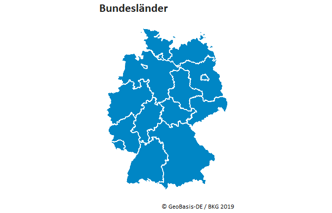

```r
ggplot(bl2017 %>% filter(EWZ>0)) + geom_sf(fill=zi_cols("ziblue") , color="White", size=1) +
  scale_fill_zi(discrete=F) + theme_zi_void(fontsize=11) + labs(title="Bundesländer")+
  labs(caption="© GeoBasis-DE / BKG 2019")
```

### Karte der Kreise mit Bundeslandoverlay

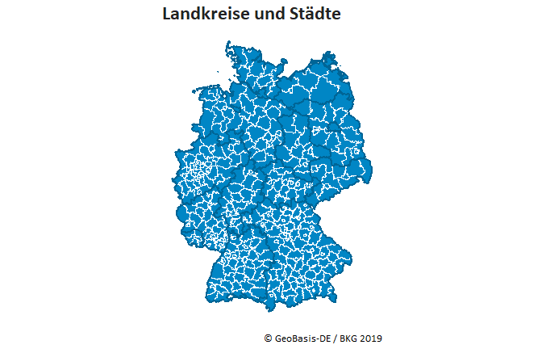

```r
ggplot(krs2017 %>% filter(EWZ>0)) +
  geom_sf(fill=zi_cols("ziblue") , color="White", size=0.2) +
  geom_sf(data=bl2017 %>% filter(EWZ>0), fill=NA , color=zi_cols("zidarkblue"), size=1) +
  scale_fill_zi(discrete=F) + theme_zi_void(fontsize = 11)  + labs(title="Landkreise und Städte") +
  labs(caption="© GeoBasis-DE / BKG 2019")
```

### Thematische Karte mit Bevölkerungszahlen

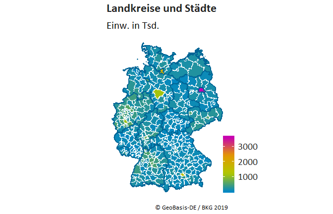

```r
ggplot(krs2017 %>% filter(EWZ>0), aes(fill=floor(EWZ/1000))) +
  geom_sf(color="White", size=0.2) +
  geom_sf(data=bl2017 %>% filter(EWZ>0), fill=NA , color=zi_cols("zidarkblue"), size=1) +
  scale_fill_zi("main4colors", discrete=F) + theme_zi_void(fontsize = 11) +
  labs(title="Landkreise und Städte", subtitle="Einw. in Tsd.", fill="") +
  labs(caption="© GeoBasis-DE / BKG 2019")
```

# Plots mit integriertem Zi Logo

Mithilfe der Funktion finalise_plot kann das Zi Logo einem Plot hinzugefügt werden.

Exemplarische Syntax:

```r
# finalise_plot(plot_name = dumbbell_plot,
# source = "Datenbasis: Vertragsärztliche Abrechnungsdaten der KVen 2009-2017",
# width_cm = 20,
# height_cm =11.25,
# save_filepath = "data/dumbbell.jpg"
# )
```

# Weitere Hinweise

## Standardexport

Grafiken können in R je nach Bedürfnis auch ohne Zi-Logo exportiert werden. Vor dem Export sollte aber die Zielgröße für den Plot feststehen. Ggf. muss nach einem testweisen Export auch die Schriftgröße angepasst werden (`theme_zi(fontsize=10)`).

Da alle Angaben zur Schriftgröße in Punkten sich auf die Ausgabegröße beziehen. Zudem kann eine Zielauflösung festgelegt werden, für den Druck festgelegt werden. Hier empfehlen sich i.d.R. 300 dpi. Als Grafikformat empfiehlt sich die Speicherung als .png Datei, da hier eine verlustfreie Komprimierung zum Einsatz kommt. Sollte eine Weiterbearbeitung der Datei in einem Layout Programm (bspw. Adobe InDesign) vorgesehen sein, empfiehlt sich der Export in einem Vektor-Format wie insb. PDF.

Beispiel Syntax für Standard Powerpoint Format:

```r
# ggsave(plot = dumbbell_plot +
#          theme_zi_titels(fontsize=14) +
#          theme(plot.title=element_blank(),
#                plot.subtitle=element_blank(),
#                legend.position = c(.8,.05),
#                legend.direction = "horizontal") +
#          labs(x="",y="Anzahl in Mio"),
#        filename="Export_Dumbbell_PPTX.png",
#        width=22.2, height=12.57, units = "cm" , dpi=300)
```